# FDA

July 19, 2019

Reference:

Analysis of Continuous Glucose Monitoring in Pregnant Women With Diabetes: Distinct Temporal Patterns of Glucose Associated With Large-for-Gestational-Age Infants

Graham R. Law, George T.H. Ellison, Anna L. Secher, Peter Damm, Elisabeth R. Mathiesen, Rosemary Temple, Helen R. Murphy, Eleanor M. Scott Diabetes Care Jul 2015, 38 (7) 1319-1325; DOI: 10.2337/dc15-0070

## Functional Response Model

### A simple FDA model without considering device groups

In what follows, we use a subset of dataset at the fixed day of the 5th visit . Let us consider $y_{i}(t)$ as daily observed glucose levels over time at the 5th visit for a given $i$th participant.

$$y_{i}(t)=x_{i}(t)+\varepsilon_{i}(t), \ \ i = 1,\dots, 213.$$
with the base function expansion
$$x_{i}(t)=\sum_{j=1}^{J}c_{ij}\phi_{j}(t)=c_{i}^{\top}\phi(t),$$
where $c_{1},c_{2},\dots,c_{J}$ are coefficients and $\phi_{1}(t),\phi_{2}(t),\dots,\phi_{J}(t)$ are basis functions.

```r
library(fda)
library(tibble)

# pick a subset of dataset: ds_cgm_sub10.RDS

ds_cgm_sub10 <- readRDS("../data/ds_cgm_sub10.RDS")
glimpse(ds_cgm_sub10)
```

```
## Observations: 20,637
## Variables: 13
## $ pt_id                          <fct> 175, 175, 175, 175, 175, 175, 1...
## $ trt_group                      <fct> CGM Only, CGM Only, CGM Only, C...
## $ pt_status                      <fct> Completed, Completed, Completed...
## $ visit                          <fct> Week 26 Visit, Week 26 Visit, W...
## $ visitnum                       <fct> 5, 5, 5, 5, 5, 5, 5, 5, 5, 5, 5...
## $ visit_dt_days_from_enroll_lag7 <dbl> 243, 243, 243, 243, 243, 243, 2...
## $ visit_dt_days_from_enroll      <dbl> 250, 250, 250, 250, 250, 250, 2...
## $ device_dt_tm_days_from_enroll  <dbl> 243, 243, 243, 243, 243, 243, 2...
## $ device_visit_period_day        <dbl> 1, 1, 1, 1, 1, 1, 1, 1, 1, 1, 1...
## $ device_tm                      <drtn> 269 secs, 568 secs, 868 secs, ...
## $ device_tm_numeric              <dbl> 269, 568, 868, 1168, 1468, 1768...
## $ device_tm_bin                  <dbl> 1, 2, 3, 4, 5, 6, 7, 8, 9, 10, ...
## $ glucose_value                  <dbl> 283, 289, 299, 311, 320, 325, 3...
```

```r
table(ds_cgm_sub10$trt_group, droplevels(ds_cgm_sub10$pt_id))
```

```
##
##             112  160  175  201   22  232  245  276  277   40
##   CGM Only    0 2080 2060 2041 2037    0    0 2080    0    0
##   CGM+BGM  2209    0    0    0    0 2132 2104    0 2081 1813
```

How do we get the estimate of the coefficient vector $\hat c$?

Goal: minimize the compound fitting criterion that trades off curve roughness against lack of data fit. The roughness penalty approach uses a large number of basis functions, possibly extending to one basis function per observation and even beyond, but at the same time imposing smoothness by penalizing some measure of function complexity.

The compound fitting criterion is
$$F(c)=\sum_{j=1}^{288}[y(t_{j})-x(t_{j})]^{2} + \lambda \times Penalty,$$
where $\lambda >0$ is the smoothing parameter and the choices of Penalty are
$$(1) \ Pen_{2} (x)=\int [D^{2}x(t)]^{2}dt$$
If we are interested in the second derivative $D^2x$ of $x$, chances are that we want it to appear to be smooth. This suggests that we ought to penalize the curvature of the second derivative, that is, use the roughness measure
$$(2) \ Pen_{4} (x)=\int [D^{4}x(t)]^{2}dt.$$

Then the estimate of the coefficient vector $\hat c$ is
$$\hat c = \Big(\Phi^{\top}\Phi + \lambda \int \phi^{\top}(t)\phi(t)dt\Big)^{-1}\Phi^{\top}y.$$

If $\lambda \to 0,$ then we fit the data as closely as possible with the selected basis set, sometimes at the expense of some fairly wild variations in the approximating function.

Then how do we choose $\lambda?$ The generalized cross-validation measure GCV developed by Craven and Wahba (1979)

```r
# pick a daily dataset for both group and for CGM only using subset 10

both_by_day <- function(pick){
  subset(ds_cgm_sub10, trt_group == "CGM+BGM" &
                          device_visit_period_day == pick)
}

CGM_by_day <- function(pick){
  subset(ds_cgm_sub10, trt_group == "CGM Only" &
                          device_visit_period_day == pick)
}

both_by_day(pick = 1)
CGM_by_day(pick = 1)

library(tidyverse)
```

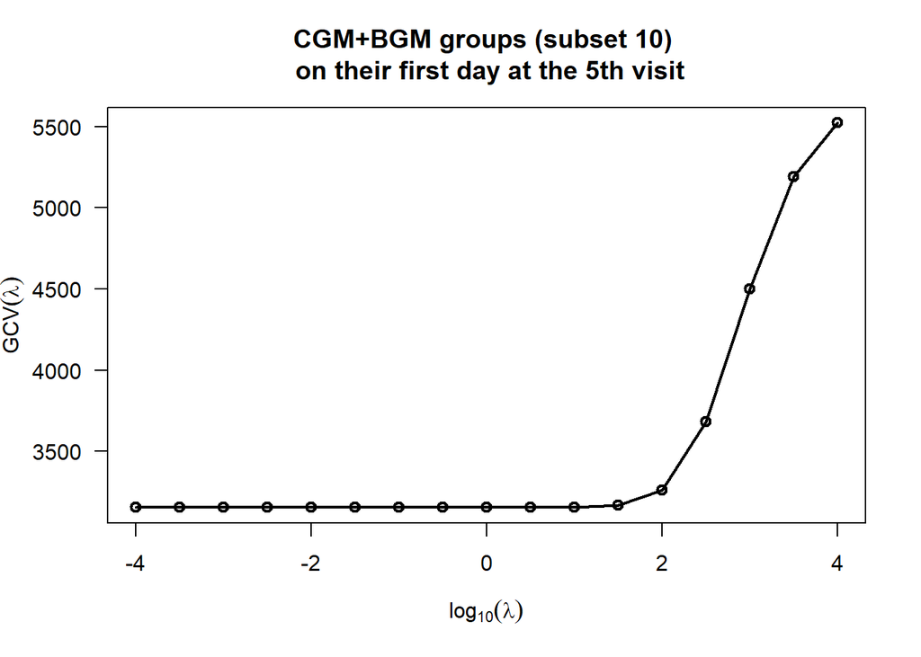

```r
both_by_day_gcv <- function(pick){
  both_by_day(pick) %>%
  select(pt_id, device_tm_bin, glucose_value) %>%
  spread(key = pt_id, value = glucose_value)
}


both_by_day_gcv(pick = 1)
# both_by_day_gcv(pick = 2)
both_by_day_gcv(pick = 3)
both_by_day_gcv(pick = 4)
# both_by_day_gcv(pick = 5)

CGM_by_day_gcv <- function(pick){
  CGM_by_day(pick) %>%
  select(pt_id, device_tm_bin, glucose_value) %>%
  spread(key = pt_id, value = glucose_value)
}

CGM_by_day_gcv(pick = 1)
CGM_by_day_gcv(pick = 2)
CGM_by_day_gcv(pick = 3)
CGM_by_day_gcv(pick = 4)
CGM_by_day_gcv(pick = 5)

# missing a lot.. -> complete case studies

library(functional)

both_by_day_gcv_finite <- function(pick){
  tmp <- both_by_day_gcv(pick)[apply(both_by_day_gcv(pick), 1, Compose(is.finite, all)),]
  glucose_matrix  <-as.matrix(tmp[,2:6])
  rownames(glucose_matrix ) <- tmp$device_tm_bin
  return(glucose_matrix)
}

both_by_day_gcv_finite(pick = 1)
# both_by_day_gcv_finite(pick = 2)
both_by_day_gcv_finite(pick = 3)
both_by_day_gcv_finite(pick = 4)
# both_by_day_gcv_finite(pick = 5)

CGM_by_day_gcv_finite <- function(pick){
  tmp <- CGM_by_day_gcv(pick)[apply(CGM_by_day_gcv(pick), 1, Compose(is.finite, all)),]
  glucose_matrix  <-as.matrix(tmp[,2:6])
  rownames(glucose_matrix ) <- tmp$device_tm_bin
  return(glucose_matrix)
}

CGM_by_day_gcv_finite(pick = 1)
CGM_by_day_gcv_finite(pick = 2)
CGM_by_day_gcv_finite(pick = 3)
CGM_by_day_gcv_finite(pick = 4)
CGM_by_day_gcv_finite(pick = 5)


loglam         = seq(-4,4,by=0.5)
Gcvsave        = rep(NA, length(loglam))
names(Gcvsave) = loglam
Dfsave         = Gcvsave


# Reference: Knots were placed at 120-min intervals over each 24-h measurement period,

bspline_basis <- create.bspline.basis(rangeval = c(0,86400),
                                    breaks = seq(0, 86400, by = 7200),
                                    norder = 5)

# number of basis functions (16) = order (5) + number of interior knots (11)
# The order of a spline is four by default, corresponding to cubic polynomial segments
# the five B-splines corresponding to 11 equally spaced interior knots over the interval [0,86400]

# Fix the order of the spline basis to be at least two higher than the highest order derivative to be used.

bspline_basis$names

# (1) both

for(i in 1:length(loglam)){
  bspline_fdpar  = fdPar(bspline_basis, Lfdobj = 3, 10^loglam[i])
  bspline_fda = smooth.basis(rownames(both_by_day_gcv_finite(pick = 1)),
                             both_by_day_gcv_finite(pick = 1), bspline_fdpar)
  Gcvsave[i] = sum(bspline_fda$gcv)
  Dfsave[i]  = bspline_fda$df
}


plot(loglam, Gcvsave, 'o', las=1, xlab=expression(log[10](lambda)),
     ylab=expression(GCV(lambda)), lwd=2, main = "CGM+BGM groups (subset 10) \n on their first day at the 5th visit" )
```

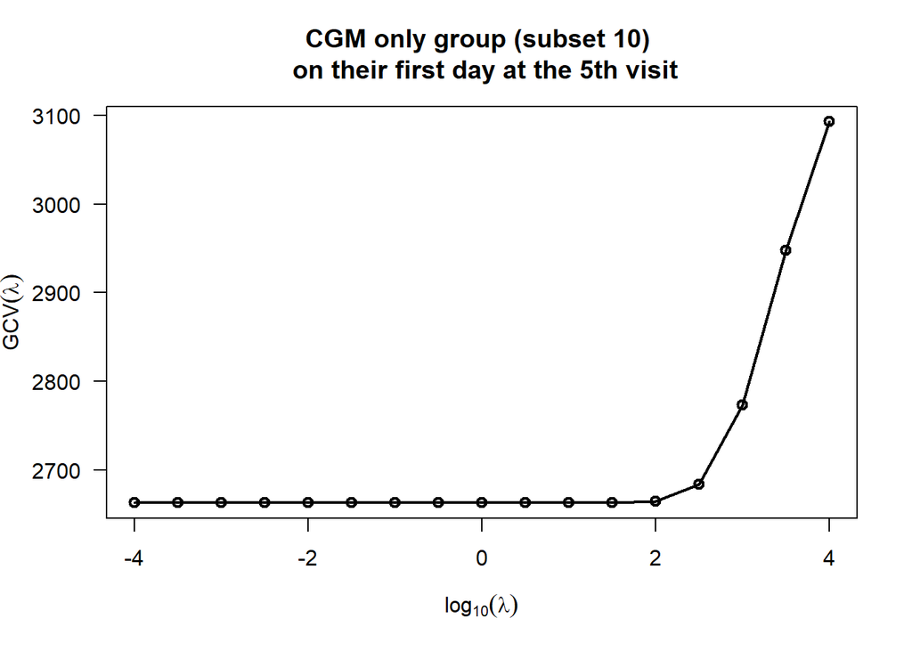

```r
# (2) CGM only

for(i in 1:length(loglam)){
  bspline_fdpar  = fdPar(bspline_basis, Lfdobj = 3, 10^loglam[i])
  bspline_fda = smooth.basis(rownames(CGM_by_day_gcv_finite(pick = 1)),
                             CGM_by_day_gcv_finite(pick = 1), bspline_fdpar)
  Gcvsave[i] = sum(bspline_fda$gcv)
  Dfsave[i]  = bspline_fda$df
}


plot(loglam, Gcvsave, 'o', las=1, xlab=expression(log[10](lambda)),
     ylab=expression(GCV(lambda)), lwd=2, main = "CGM only group (subset 10) \n on their first day at the 5th visit")
```

```r
# along with a roughness penalty on their third derivative
# with smoothing parameter lambda = 100

bspline_fdpar <- fdPar(bspline_basis, Lfdobj = 3, lambda = 100)

both_by_day_fda <- function(pick){
  smooth.basis(both_by_day(pick)$device_tm,both_by_day(pick)$glucose_value, bspline_fdpar)$fd
}

both_by_day_fda(pick = 1)$coefs
```

```
##               [,1]
## bspl5.1  151.86288
## bspl5.2  142.42600
## bspl5.3  158.87846
## bspl5.4  108.02301
## bspl5.5  132.71394
## bspl5.6  115.93226
## bspl5.7  126.67811
## bspl5.8   66.11499
## bspl5.9  155.73997
## bspl5.10 230.74290
## bspl5.11 257.51805
## bspl5.12 211.38454
## bspl5.13 168.92349
## bspl5.14 121.16481
## bspl5.15 200.83798
## bspl5.16 155.70845
```

```r
CGM_by_day_fda <- function(pick){
  smooth.basis(CGM_by_day(pick)$device_tm,CGM_by_day(pick)$glucose_value, bspline_fdpar)$fd
}

CGM_by_day_fda(pick = 1)$coefs
```

```
##               [,1]
## bspl5.1  189.06322
## bspl5.2  257.98394
## bspl5.3  164.16601
## bspl5.4  301.55246
## bspl5.5  149.81973
## bspl5.6  248.06685
## bspl5.7  142.36771
## bspl5.8   72.04844
## bspl5.9  202.62765
## bspl5.10 103.29143
## bspl5.11 176.79795
## bspl5.12 155.04218
## bspl5.13 180.68876
## bspl5.14 194.36678
## bspl5.15 145.53546
## bspl5.16 157.83471
```

```r
# plot of glucose levels at or across specific points in time

par(family = 'mono')

# (1) both group

plot(both_by_day(pick = 1)$device_tm,both_by_day(pick = 1)$glucose_value, cex = .5,
     xlab = "Time", ylab = "Glucose level (mg/dl)",
     main = "CGM+BGM groups (subset 10) \n on their first day at the 5th visit",
     cex.axis = 1, cex.main = 1, xaxt = "n")
axis(1, seq(0,86400, 21600), font=2,cex.axis=0.8,
     labels = c("00:00","06:00","12:00","18:00","24:00"))
plot(both_by_day_fda(pick = 1), add = T, col = "red", lwd = 5)
```

```
## [1] "done"
```

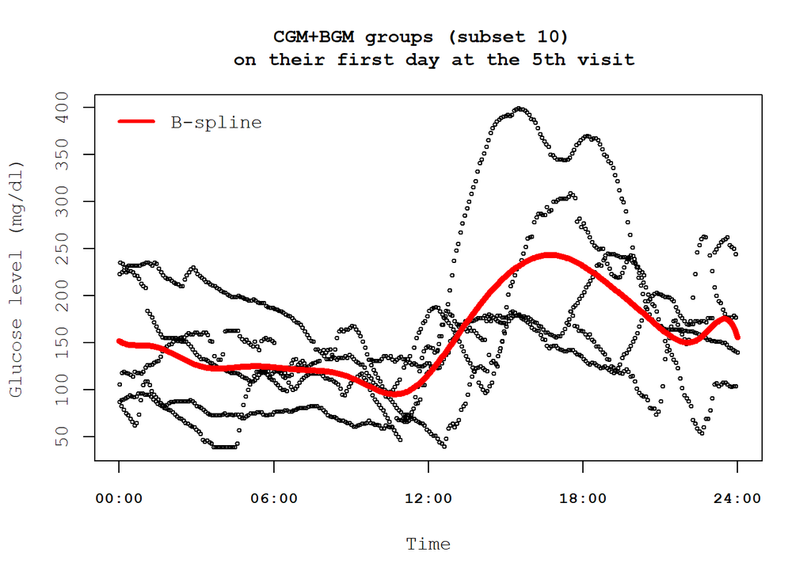

```r
legend("topleft", col = "red", legend = "B-spline",
       bty = "n", inset = 0.01, lwd = 3)
```

```r
# plot of measures of change (velocity), first derivative

plot(both_by_day_fda(pick = 1), Lfdobj = 1, main = "Velocity of the curve", xaxt = "n")
```

```
## [1] "done"
```

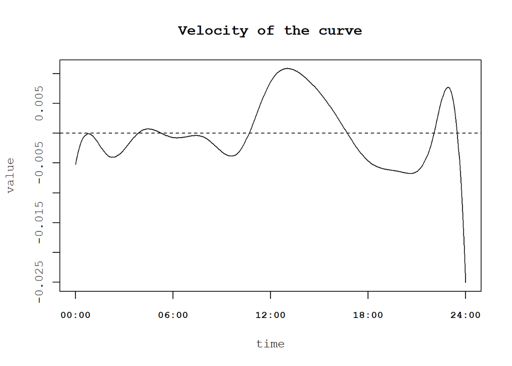

```r
axis(1, seq(0,86400, 21600), font=2,cex.axis=0.8,
     labels = c("00:00","06:00","12:00","18:00","24:00"))
```

```r
# plot of rate of change (acceleration), second derivative

plot(both_by_day_fda(pick = 1), Lfdobj = 2, main = "Acceleration of the curve", xaxt = "n")
```

```
## [1] "done"
```

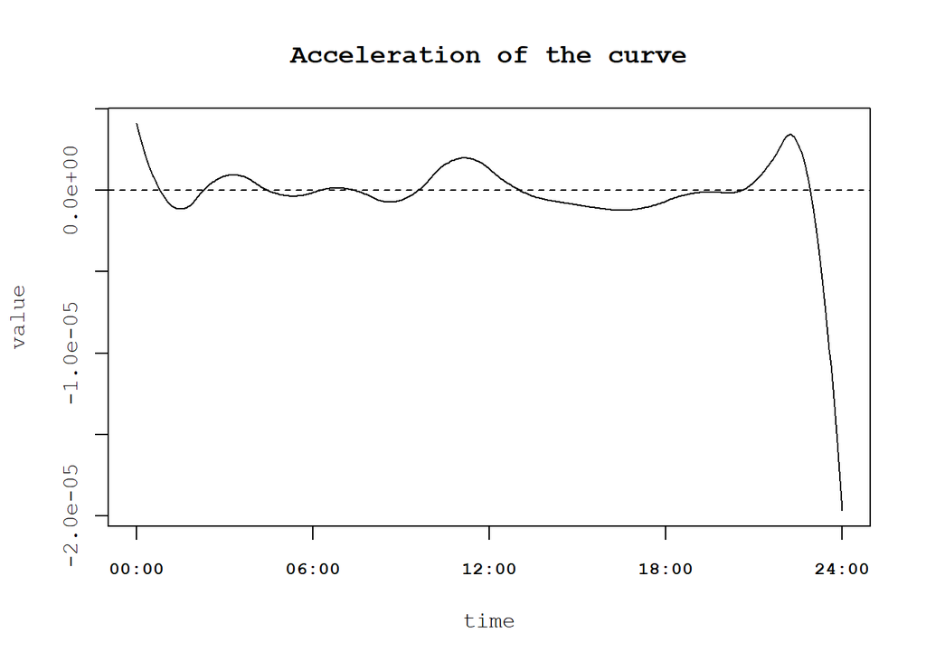

```r
axis(1, seq(0,86400, 21600), font=2,cex.axis=0.8,
     labels = c("00:00","06:00","12:00","18:00","24:00"))
```

```r
# (2) CGM only group

plot(CGM_by_day(pick = 1)$device_tm,CGM_by_day(pick = 1)$glucose_value, cex = .5,
     xlab = "Time", ylab = "Glucose level (mg/dl)",
     main = "CGM only group (subset 10) \n on their first day at the 5th visit",
     cex.axis = 1, cex.main = 1, xaxt = "n")
axis(1, seq(0,86400, 21600), font=2,cex.axis=0.8,
     labels = c("00:00","06:00","12:00","18:00","24:00"))
plot(CGM_by_day_fda(pick = 1), add = T, col = "red", lwd = 5)
```

```
## [1] "done"
```

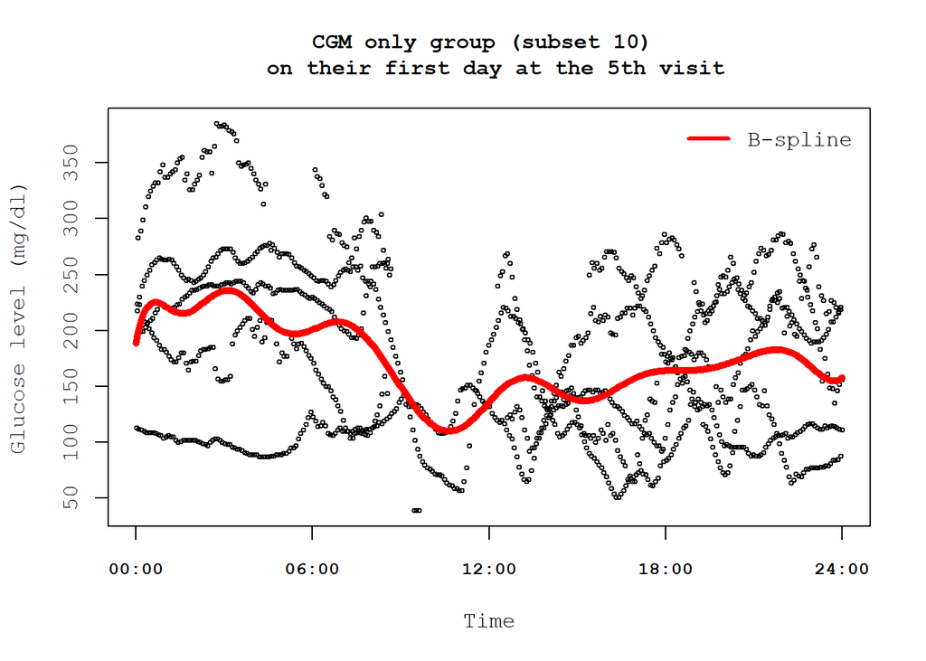

```r
legend("topright", col = "red", legend = "B-spline",
       bty = "n", inset = 0.01, lwd = 3)
```

```r
# plot of measures of change (velocity), first derivative

plot(CGM_by_day_fda(pick = 1), Lfdobj = 1, main = "Velocity of the curve", xaxt = "n")
```

```
## [1] "done"
```

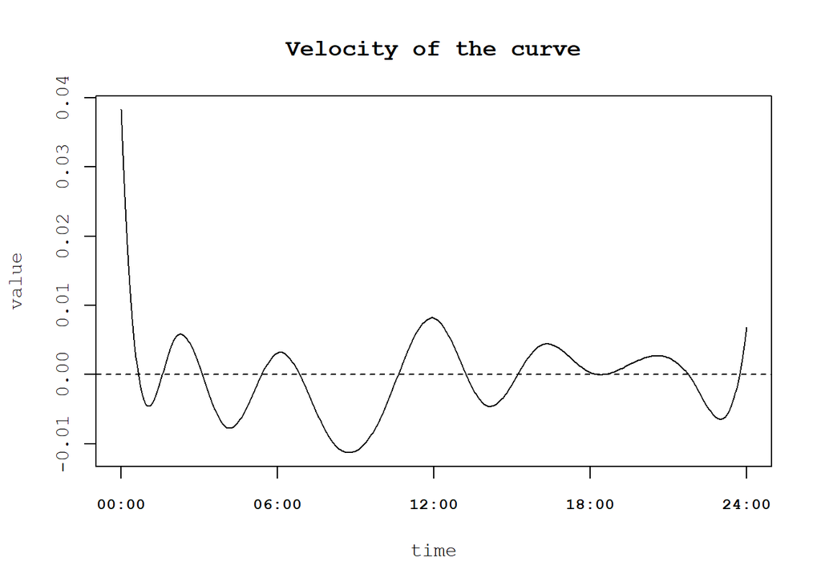

```r
axis(1, seq(0,86400, 21600), font=2,cex.axis=0.8,
     labels = c("00:00","06:00","12:00","18:00","24:00"))
```

```r
# plot of rate of change (acceleration), second derivative

plot(CGM_by_day_fda(pick = 1), Lfdobj = 2, main = "Acceleration of the curve", xaxt = "n")
```

```
## [1] "done"
```

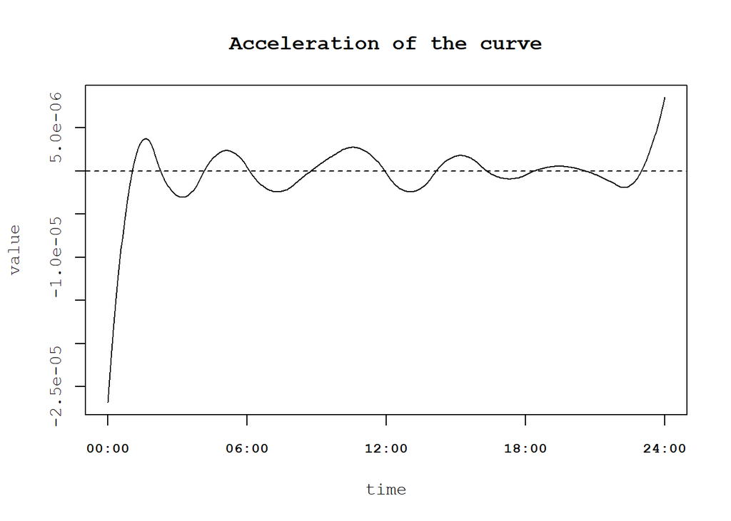

```r
axis(1, seq(0,86400, 21600), font=2,cex.axis=0.8,
     labels = c("00:00","06:00","12:00","18:00","24:00"))
```

Next we estimate $\Sigma_{e}$, which we assume is diagonal. Consequently, we need only estimate the variance of the residuals across participants for each day at a given vist.